# R Notebook

## Problem1— Using ANN for Classifying News Articles

For this problem, we are going to use reuters dataset. It is a set of short newswires along with their topics published by Reuters in 1986. It is a simple, widely used toy dastaset for text classification. You are going to use a simple feedforward neural network to classify reuters news into 46 different topics/classes. The reuters dataset comes packaged as part of Keras . Import the dataset from keras using the following commands:

```r
library(keras)
reuters = dataset_reuters(num_words=10000)
```

```r
str(reuters$train$x)
```

```
List of 8982
 $ : int [1:87] 1 2 2 8 43 10 447 5 25 207 ...
 $ : int [1:56] 1 3267 699 3434 2295 56 2 7511 9 56 ...
 $ : int [1:139] 1 53 12 284 15 14 272 26 53 959 ...
 $ : int [1:224] 1 4 686 867 558 4 37 38 309 2276 ...
 $ : int [1:101] 1 8295 111 8 25 166 40 638 10 436 ...
 $ : int [1:116] 1 4 37 38 309 213 349 1632 48 193 ...
 $ : int [1:100] 1 56 5539 925 149 8 16 23 931 3875 ...
 $ : int [1:100] 1 53 648 26 14 749 26 39 6207 5466 ...
 $ : int [1:82] 1 178 53 321 26 14 948 26 178 39 ...
 $ : int [1:106] 1 56 7224 81 40 1175 174 2 6 1793 ...
 $ : int [1:31] 1 245 273 207 156 53 74 160 26 14 ...
 $ : int [1:59] 1 56 141 5618 1607 149 8 16 33 223 ...
 $ : int [1:65] 1 2 81 8 16 625 42 120 7 1679 ...
 $ : int [1:316] 1 248 409 166 1461 1284 3906 8 4 495 ...
```

[output cut: 86 more lines]

This means that the first article consists of the words with indices 1,2,2,8,etc. As you can see, the examples in the train and test data are vectors of varying lengths. Neural Networks requires a matrix where each row represents an example and each column represent an attribute of that example. Therefore, to prepare this data for neural networks we need to make sure that all examples have the same number of columns ( that is, they are vectors of the same length). To do this, we do one- hot encoding of each example to turn them into vectors of 0s and 1s. This would mean for instance, turning the sequence [1,2,2,8,….] into a 10000 dimensional vector that would be all zeros except for indices 1,2,8, etc. In other words, we turn each news article into a 10000 dimensional binary vector which indicates which of the top 10000 frequent words occur in that article. You can use the following r function to do this one-hot-encoding:

```r
one_hot_encoding = function(x, dimension=10000) {
  encoded = matrix(0, length(x), dimension)
  for (i in 1:length(x))
  encoded[i, x[[i]]] = 1
  encoded
}
```

Where x is the list of examples for which you want to do one-hot-encoding. Call this function on reuters$train$x and reuters$test$x to get the one-hot encoding of the train and test examples. This will produce a matrix with dimensions (8982,10000) for the train data and a matrix with dimensions(2246, 10000) for the test data. You can now use these matrices to train and test your neural network model.

```r
reuters_train = one_hot_encoding(reuters$train$x)
reuters_test = one_hot_encoding(reuters$test$x)
```

**Q1. (5 pts)** Create an ANN model to classify reuters news article into 46 classes (note that reuters$train$y and reuters$test$y are vectors of integers between 0-45 representing the category of each news article). Use at least two hidden layers and compute the accuracy of your model on the test set. Unlike the fashion Mnist dataset where each image had to be flattened into a one dimensional vector, for the reuters dataset, you do not need the flatten layer before the dense layer as each observation (news article) is already one dimensional.

```r
model <- keras_model_sequential()
model %>%
        layer_dense( units = 50, activation = "relu", input_shape = 10000) %>%
        layer_dense( units = 50, activation = "relu") %>%
        layer_dense( units = 50, activation = "relu") %>%
        layer_dense(units = 46, activation = 'softmax')
```

```r
set.seed(123)
model %>% compile (
     loss = 'sparse_categorical_crossentropy',
     optimizer = 'adam',
     metrics = 'accuracy')
```

```r
history = model %>% fit (x = reuters_train, y = reuters$train$y)
```

```r
score <- model %>% evaluate(reuters_test, reuters$test$y, verbose = 2)
```

```
71/71 - 0s - loss: 1.2323 - accuracy: 0.7898
71/71 - 0s - loss: 1.2323 - accuracy: 0.7898
```

```r
cat('Test accuracy:', score[2], "\n")
```

```
Test accuracy: 0.7898486
```

**Q2. (5 pts)** Split the train data into train/validation set. Use the first 1000 examples in reuters$train for validation and the rest for training your model. Use “tfruns” package to tune your ANN’s hyperparameters including, the number of nodes in each hidden layer, the activation function in each hidden layer, batch_size, learning_rate, and the number of epochs). Validate each model on the validation set.  
Answer the following questions:  
1- Which model ( which hyper-parameter combination) resulted in the best accuracy on the validation data? Make sure that you print the returned value from tfruns and report the  
run with the highest validation accuracy.  
2- Print the learning curve of your best model. Does your best model still overfit?  
3- Does your validation_loss stop decreasing after several epochs? If so, at roughly which epoch  
does your validation_loss stop decreasing?

```r
reuters_validation_x = one_hot_encoding(reuters$train$x[1:1000])
validation_labels = reuters$train$y[1:1000]

reuters_train = one_hot_encoding(reuters$train$x[1001:length(reuters$train$x)])
reuters_train_labels = reuters$train$y[1001:length(reuters$train$y)]
```

```r
library(tfruns)
```

```r
runs <- tuning_run("reuters.R",
                   flags = list (
                     nodes = c(64, 128, 392),
                     learning_rate = c(0.01, 0.05, 0.001, 0.0001),
                     batch_size = c(100, 200, 500, 1000),
                     epochs = c(30,50,100),
                     activation = c("relu","sigmoid","tanh")
                   ), sample = 0.02)
```

```
432 total combinations of flags (sampled to 8 combinations)
```

```r
y
```

```
Training run 1/8 (flags = list(64, 0.001, 500, 100, "tanh"))
Using run directory runs/2020-11-01T18-47-32Z
```

```
> FLAGS <- flags(
+         flag_numeric("nodes", 50),
+         flag_numeric("batch_size", 100),
+         flag_string("activation", "relu"),
+       .... [TRUNCATED]

> model <- keras_model_sequential()

> model %>%
+         layer_dense( units = FLAGS$nodes, activation = FLAGS$activation, input_shape = 10000) %>%
+         layer_dense( units = FLAGS$n .... [TRUNCATED]

> set.seed(123)

> model %>% compile (
+         loss = 'sparse_categorical_crossentropy',
+         optimizer = optimizer_adam(lr=FLAGS$learning_rate),
+         metr .... [TRUNCATED]

> model %>% fit (x = reuters_train, y = reuters_train_labels, epochs = FLAGS$epochs, batch_size = FLAGS$batch_size, validation_data = list(reuters_val .... [TRUNCATED]
```

```
Error occurred resetting tf graph: AttributeError: module 'tensorflow' has no attribute 'reset_default_graph'
Run completed: runs/2020-11-01T18-47-32Z

Training run 2/8 (flags = list(128, 1e-04, 500, 30, "sigmoid"))
Using run directory runs/2020-11-01T18-48-09Z
```

[output not shown]

```
Error occurred resetting tf graph: AttributeError: module 'tensorflow' has no attribute 'reset_default_graph'
Run completed: runs/2020-11-01T18-48-09Z

Training run 3/8 (flags = list(128, 0.01, 200, 30, "relu"))
Using run directory runs/2020-11-01T18-48-25Z
```

[output not shown]

```
Error occurred resetting tf graph: AttributeError: module 'tensorflow' has no attribute 'reset_default_graph'
Run completed: runs/2020-11-01T18-48-25Z

Training run 4/8 (flags = list(392, 0.01, 100, 50, "sigmoid"))
Using run directory runs/2020-11-01T18-48-42Z
```

[output not shown]

```
Error occurred resetting tf graph: AttributeError: module 'tensorflow' has no attribute 'reset_default_graph'
Run completed: runs/2020-11-01T18-48-42Z

Training run 5/8 (flags = list(392, 0.05, 1000, 100, "tanh"))
Using run directory runs/2020-11-01T18-50-06Z
```

[output not shown]

```
Error occurred resetting tf graph: AttributeError: module 'tensorflow' has no attribute 'reset_default_graph'
Run completed: runs/2020-11-01T18-50-06Z

Training run 6/8 (flags = list(392, 0.05, 200, 30, "tanh"))
Using run directory runs/2020-11-01T18-51-34Z
```

[output not shown]

```
Error occurred resetting tf graph: AttributeError: module 'tensorflow' has no attribute 'reset_default_graph'
Run completed: runs/2020-11-01T18-51-34Z

Training run 7/8 (flags = list(64, 1e-04, 200, 100, "relu"))
Using run directory runs/2020-11-01T18-52-12Z
```

[output not shown]

```
Error occurred resetting tf graph: AttributeError: module 'tensorflow' has no attribute 'reset_default_graph'
Run completed: runs/2020-11-01T18-52-12Z

Training run 8/8 (flags = list(128, 1e-04, 100, 30, "tanh"))
Using run directory runs/2020-11-01T18-52-54Z
```

[output not shown]

```
Error occurred resetting tf graph: AttributeError: module 'tensorflow' has no attribute 'reset_default_graph'
Run completed: runs/2020-11-01T18-52-54Z
```

```r
runs
```

```
Data frame: 8 x 25
```

|  | run_dir | metric_loss | metric_accuracy | metric_val_loss | metric_val_accuracy |
| --- | --- | --- | --- | --- | --- |
| 1 | runs/2020-11-01T18-52-54Z | 0.0934 | 0.9585 | 0.8992 | 0.812 |
| 2 | runs/2020-11-01T18-52-12Z | 0.0722 | 0.9614 | 1.2215 | 0.805 |
| 3 | runs/2020-11-01T18-51-34Z | 9.8711 | 0.2185 | 11.4770 | 0.222 |
| 4 | runs/2020-11-01T18-50-06Z | 2.6274 | 0.3320 | 2.7410 | 0.354 |
| 5 | runs/2020-11-01T18-48-42Z | 0.0643 | 0.9608 | 2.0082 | 0.784 |
| 6 | runs/2020-11-01T18-48-25Z | 0.1362 | 0.9549 | 2.3400 | 0.778 |
| 7 | runs/2020-11-01T18-48-09Z | 2.1622 | 0.4495 | 2.1441 | 0.467 |
| 8 | runs/2020-11-01T18-47-32Z | 0.0512 | 0.9629 | 1.2643 | 0.791 |

```
# ... with 20 more columns:
#   flag_nodes, flag_batch_size, flag_activation, flag_learning_rate, flag_epochs,
#   epochs, epochs_completed, metrics, model, loss_function, optimizer,
#   learning_rate, script, start, end, completed, output, source_code, context, type
```

```r
reuters_train = one_hot_encoding(reuters$train$x)
reuters_test = one_hot_encoding(reuters$test$x)
```

```r
model <- keras_model_sequential()
model %>%
        layer_dense( units = 128, activation = "tanh", input_shape = 10000) %>%
        layer_dense( units = 128, activation = "tanh") %>%
        layer_dense( units = 128, activation = "tanh") %>%
        layer_dense(units = 46, activation = 'softmax')
```

```r
set.seed(123)
model %>% compile (
        loss = 'sparse_categorical_crossentropy',
        optimizer = optimizer_adam(lr=0.0001),
        metrics = 'accuracy')

model %>% fit (x = reuters_train, y = reuters$train$y, epochs = 30, batch_size = 100)
```

```r
history = model %>% fit (x = reuters_train, y = reuters$train$y)
```

```r
history
```

```
Final epoch (plot to see history):
    loss: 0.08542
accuracy: 0.9546
```

## Problem2——Predicting Baseball players’ salaries

1. (1p) Download the dataset hitters.csv and explore the overall structure of the dataset using the str() function. Get a summary statistics of each variable. Answer the following questions:
1. How many observations do you have in the data?
2. How many categorical and numeric variables you have in your data?
3. Is there any missing value?
4. Draw the histogram of salary. Interpret what you see in the histogram.

```r
hitters = read.csv("hitters.csv")
```

```r
str(hitters)
```

```
'data.frame':   322 obs. of  20 variables:
 $ AtBat    : int  293 315 479 496 321 594 185 298 323 401 ...
 $ Hits     : int  66 81 130 141 87 169 37 73 81 92 ...
 $ HmRun    : int  1 7 18 20 10 4 1 0 6 17 ...
 $ Runs     : int  30 24 66 65 39 74 23 24 26 49 ...
 $ RBI      : int  29 38 72 78 42 51 8 24 32 66 ...
 $ Walks    : int  14 39 76 37 30 35 21 7 8 65 ...
 $ Years    : int  1 14 3 11 2 11 2 3 2 13 ...
 $ CAtBat   : int  293 3449 1624 5628 396 4408 214 509 341 5206 ...
 $ CHits    : int  66 835 457 1575 101 1133 42 108 86 1332 ...
 $ CHmRun   : int  1 69 63 225 12 19 1 0 6 253 ...
 $ CRuns    : int  30 321 224 828 48 501 30 41 32 784 ...
 $ CRBI     : int  29 414 266 838 46 336 9 37 34 890 ...
 $ CWalks   : int  14 375 263 354 33 194 24 12 8 866 ...
 $ League   : chr  "A" "N" "A" "N" ...
 $ Division : chr  "E" "W" "W" "E" ...
 $ PutOuts  : int  446 632 880 200 805 282 76 121 143 0 ...
 $ Assists  : int  33 43 82 11 40 421 127 283 290 0 ...
 $ Errors   : int  20 10 14 3 4 25 7 9 19 0 ...
 $ Salary   : num  NA 475 480 500 91.5 750 70 100 75 1100 ...
 $ NewLeague: chr  "A" "N" "A" "N" ...
```

```r
summary(hitters)
```

```
     AtBat            Hits         HmRun            Runs             RBI
 Min.   : 16.0   Min.   :  1   Min.   : 0.00   Min.   :  0.00   Min.   :  0.00
 1st Qu.:255.2   1st Qu.: 64   1st Qu.: 4.00   1st Qu.: 30.25   1st Qu.: 28.00
 Median :379.5   Median : 96   Median : 8.00   Median : 48.00   Median : 44.00
 Mean   :380.9   Mean   :101   Mean   :10.77   Mean   : 50.91   Mean   : 48.03
 3rd Qu.:512.0   3rd Qu.:137   3rd Qu.:16.00   3rd Qu.: 69.00   3rd Qu.: 64.75
 Max.   :687.0   Max.   :238   Max.   :40.00   Max.   :130.00   Max.   :121.00

     Walks            Years            CAtBat            CHits            CHmRun
 Min.   :  0.00   Min.   : 1.000   Min.   :   19.0   Min.   :   4.0   Min.   :  0.00
 1st Qu.: 22.00   1st Qu.: 4.000   1st Qu.:  816.8   1st Qu.: 209.0   1st Qu.: 14.00
 Median : 35.00   Median : 6.000   Median : 1928.0   Median : 508.0   Median : 37.50
 Mean   : 38.74   Mean   : 7.444   Mean   : 2648.7   Mean   : 717.6   Mean   : 69.49
 3rd Qu.: 53.00   3rd Qu.:11.000   3rd Qu.: 3924.2   3rd Qu.:1059.2   3rd Qu.: 90.00
 Max.   :105.00   Max.   :24.000   Max.   :14053.0   Max.   :4256.0   Max.   :548.00

     CRuns             CRBI             CWalks           League            Division
 Min.   :   1.0   Min.   :   0.00   Min.   :   0.00   Length:322         Length:322
 1st Qu.: 100.2   1st Qu.:  88.75   1st Qu.:  67.25   Class :character   Class :character
 Median : 247.0   Median : 220.50   Median : 170.50   Mode  :character   Mode  :character
 Mean   : 358.8   Mean   : 330.12   Mean   : 260.24
 3rd Qu.: 526.2   3rd Qu.: 426.25   3rd Qu.: 339.25
 Max.   :2165.0   Max.   :1659.00   Max.   :1566.00

    PutOuts          Assists          Errors          Salary        NewLeague
 Min.   :   0.0   Min.   :  0.0   Min.   : 0.00   Min.   :  67.5   Length:322
 1st Qu.: 109.2   1st Qu.:  7.0   1st Qu.: 3.00   1st Qu.: 190.0   Class :character
 Median : 212.0   Median : 39.5   Median : 6.00   Median : 425.0   Mode  :character
 Mean   : 288.9   Mean   :106.9   Mean   : 8.04   Mean   : 535.9
 3rd Qu.: 325.0   3rd Qu.:166.0   3rd Qu.:11.00   3rd Qu.: 750.0
 Max.   :1378.0   Max.   :492.0   Max.   :32.00   Max.   :2460.0
                                                  NA's   :59
```

1. There are 322 observations
2. There are 3 categorical variables and 17 numeric variables
3. There are 59 missing values in salary
4. The histogram is skewed right and the mean is around 500

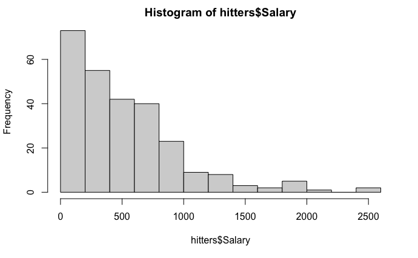

```r
hist(hitters$Salary)
```

2. (1p) remove the observation for which Salary value is missing

```r
hitters_clean = hitters[!is.na(hitters$Salary),]
```

3. (2 pt) Which predictors have most correlation with Salary? Use scattered plot, side-by-side box plots, t-test and correlation matrix to answer this question.

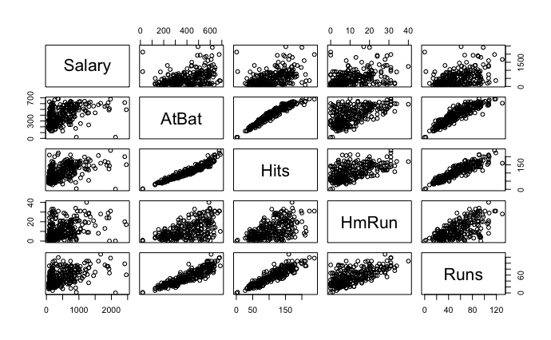

```r
plot(hitters_clean[ , c(19, 1:4)])
```

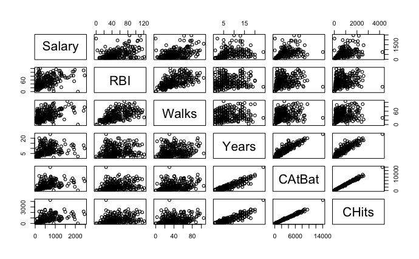

```r
plot(hitters_clean[ , c(19, 5:9)])
```

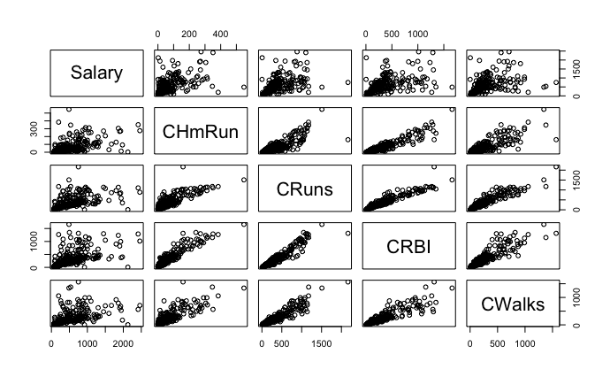

```r
plot(hitters_clean[ , c(19, 10:13)])
```

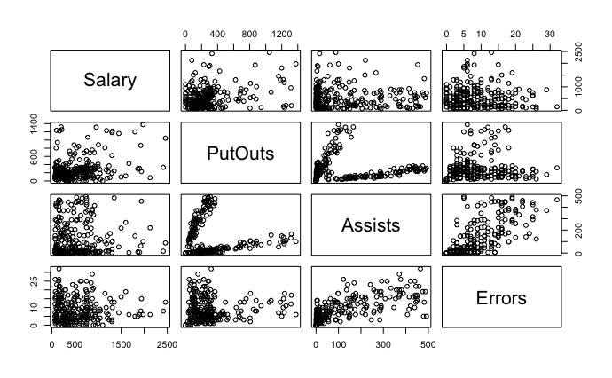

```r
plot(hitters_clean[ , c(19, 16:18)])
```

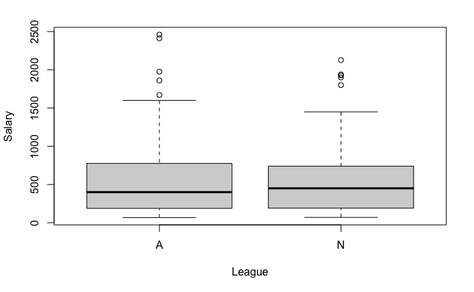

```r
boxplot(Salary~League,data = hitters_clean)
```

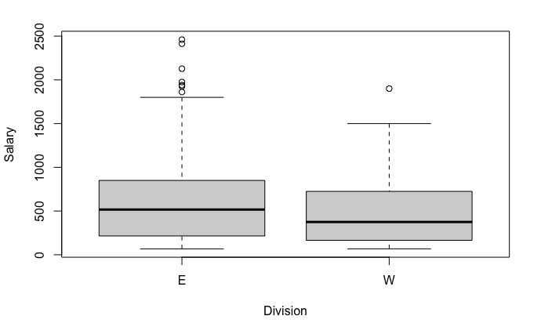

```r
boxplot(Salary~Division,data = hitters_clean)
```

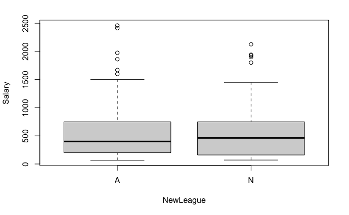

```r
boxplot(Salary~NewLeague,data = hitters_clean)
```

```r
t.test(Salary~League, data = hitters_clean)
```

```
    Welch Two Sample t-test

data:  Salary by League
t = 0.23157, df = 260.26, p-value = 0.8171
alternative hypothesis: true difference in means is not equal to 0
95 percent confidence interval:
 -96.66039 122.42448
sample estimates:
mean in group A mean in group N
       541.9995        529.1175
```

```r
t.test(Salary~Division,data = hitters_clean)
```

```
    Welch Two Sample t-test

data:  Salary by Division
t = 3.145, df = 218.46, p-value = 0.001892
alternative hypothesis: true difference in means is not equal to 0
95 percent confidence interval:
  64.73206 282.05692
sample estimates:
mean in group E mean in group W
       624.2714        450.8769
```

```r
t.test(Salary~NewLeague,data = hitters_clean)
```

```
    Welch Two Sample t-test

data:  Salary by NewLeague
t = 0.045921, df = 258.07, p-value = 0.9634
alternative hypothesis: true difference in means is not equal to 0
95 percent confidence interval:
 -107.1832  112.3016
sample estimates:
mean in group A mean in group N
       537.1130        534.5539
```

```r
cor(hitters_clean$Salary, y=hitters_clean[-c(19, 15, 14, 20)])
```

```
         AtBat      Hits     HmRun      Runs       RBI     Walks    Years    CAtBat
[1,] 0.3947709 0.4386747 0.3430281 0.4198586 0.4494571 0.4438673 0.400657 0.5261353
         CHits    CHmRun     CRuns      CRBI   CWalks   PutOuts    Assists       Errors
[1,] 0.5489096 0.5249306 0.5626777 0.5669657 0.489822 0.3004804 0.02543614 -0.005400702
```

CAtBat, CHits, CHmRun, CRuns, and CRBI have correlations greater than .5

4. Use set.seed(1) to set the random seed so I can reproduce your results.

```r
set.seed(1)
```

5. Use Caret’s “createDataPartition” method as follows to partition the dataset into hitters_train, and hitters_test (use 90% for training and 10% for testing)

```r
inTrain = createDataPartition(hitters_clean$Salary, p=0.9, list=FALSE)
hitters_train = hitters_clean[inTrain,]
hitters_test = hitters_clean[-inTrain,]
```

6. (1pt) Neural networks do not accept categorical variables and we must encode the categorical variables before training the network. All the categorical variables in this dataset are binary ( i.e., have two levels) so you can encode them by simply using iflese function to convert each to a numeric variable with two values 0 and 1.

```r
hitters_train$NewLeague = ifelse(hitters_train$NewLeague == "N", 1, 0)
hitters_train$Division = ifelse(hitters_train$Division == "W", 1, 0)
hitters_train$League = ifelse(hitters_train$League == "N", 1, 0)
```

7. (1pt)Replace the salary column with log(salary) where log is the logarithm function. This will be the attribute we want to predict.

```r
hitters_train$Salary = log(hitters_train$Salary)
```

8. (1pt) Set.seed(1) and further divide the hitters_train data into 90% training and 10% validation using Caret’s “CreateDataPartition” function

```r
toTrain = createDataPartition(hitters_train$Salary, p=0.9, list=FALSE)
hitters_train = hitters_train[toTrain , ]
hitters_val = hitters_train[-toTrain , ]
```

9. ( 3 pt) Scale the numeric attributes in the training data (except for the outcome variable, Salary). Use the column means and column standard deviations from the training data to scale both the validation and test data (please refer to slide 81, lecture 9). Note: **You should not scale the** **dummy variables you created in step 6.** You can append the categorical variables to your scaled numeric variables.

```r
hitters_scale_train = scale(hitters_train[-c(14,15,20)])

hitters_mean_train = attr(hitters_scale_train, "scaled:center")
hitters_stddevs_train = attr(hitters_scale_train, "scaled:scale")

hitters_scale_train = as.data.frame(hitters_scale_train)

hitters_scale_train$League = hitters_train[,14]
hitters_scale_train$Division = hitters_train[,15]
hitters_scale_train$NewLeague = hitters_train[,20]

hitters_scale_val = as.data.frame(scale(hitters_val[-c(14,15,20)], center = hitters_mean_train, scale = hitters_stddevs_train))
hitters_scale_val$League = hitters_val[,14]
hitters_scale_val$Division = hitters_val[,15]
hitters_scale_val$NewLeague = hitters_val[,20]

hitters_scale_test = as.data.frame(scale(hitters_test[-c(14,15,20)], center = hitters_mean_train, scale = hitters_stddevs_train))
hitters_scale_test$League = hitters_test[,14]
hitters_scale_test$Division = hitters_test[,15]
hitters_scale_test$NewLeague = hitters_test[,20]
```

9 cont. (5 pt) Create an ANN model to predict log(salary) from other attributes. Use at least two hidden layers. Use tfruns to tune your model’s hyper-parameters including, the number of nodes in each hidden layer, the activation function in each hidden layer, batch_size, learning_rate, and the number of epochs). Validate each model on the validation set. Answer the following questions: • Print the returned value from tf_runs to see the metrics for each run. Which run ( which hyper-parameter combination) gave the best mean squared error on the validation data? • Print the learning curve for your best model. Does your best model still overfit? • Does your validation_loss stop decreasing after several epochs? If so, at roughly which epoch does your validation_loss stop decreasing?